# Práctica 2. Visualización de Datos

### **Ejercicio 8**

- Descarga de la url “http://assets.datacamp.com/blog_assets/chol.txt” el dataset de Datacamp que utilizarás para este ejercicio y cárgalo en un datafrae .
- Representa el histograma de la variable `HEIGHT` del dataframe cargado del fichero anterior.
- Añade título (“Histograma de la variable Altura”), una etiqueta en el eje $x$ (“Altura (cm)”) y una etiqueta en el eje $y$ (“Frecuencia”).
- Ajusta el rango de representación entre 155 y 195, además fuerza que el histograma tenga 20 *bins*.(usa parámetro `breaks`)
- Haz que las barras del histograma sean de color azul con una grado de transparencia del 50% y el contorno de color rojo.
- Añade la curva de distribución estimada de color verde.
- Representa el mismo histograma del apartado anterior para cada valor de la variable `MORT`, recuerda utilizar la función **facet_grid()**.
- Almacena en formato **pdf** el gráfico resultante en un fichero denominado `Ejercicio8.pdf`.

```r
#
```

## Gráficos de barras con **ggplot2**

En esta sección vamos a utilizar **ggplot2** para representar gráficos de barras. Para ello vamos a utilizar la función **geom_bar()**. La forma de definir los **aes()** es muy similar a como lo hacíamos con otras funciones “geom” que ya hemos utilizado, no obstante existen pequeñas diferencias que vamos a tratar de plasmar con varios ejemplos. Empezaremos cargando el fichero `weatherAUS_distributions.RData`.

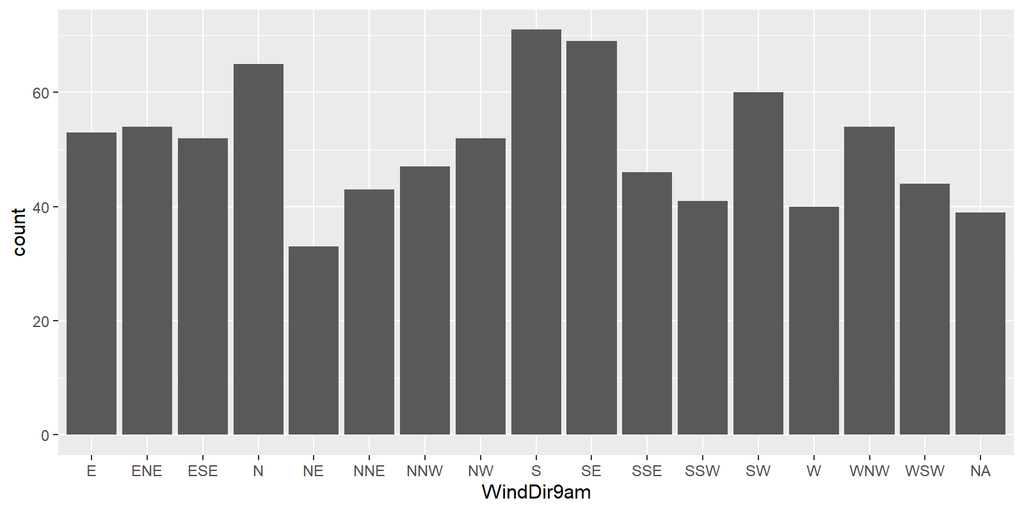

```r
load("./data/weatherAUS_distributions.RData")
ggplot(data=ds,aes(x=WindDir9am)) + geom_bar()
```

Podemos incluir más información en este tipo de gráficos. Imaginemos que queremos obtener el mismo gráfico de barras pero para dos grupos de datos proporcionados por la variable `RainToday`.

Cuando en una misma posición (`position`) debemos mostrar información diferente, se pueden realizar varios tipos de representación, por ejemplo apilada (`stacked`) como se indica en la siguiente figura. Esta es la opción por defecto.

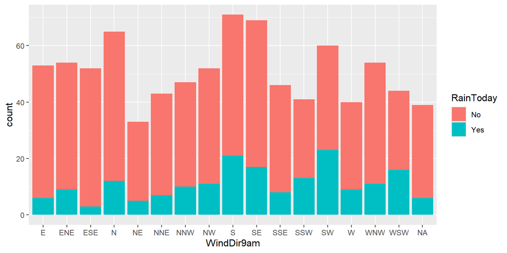

```r
ggplot(data=ds,aes(x=WindDir9am, fill=RainToday)) + geom_bar()
```

La filosofía de capas permite que estas puedan ser utilizadas en diferentes tipos de gráficos. ¿Recuerdas el ejercicio donde pediamos girar a 45 grados las etiquetas de un gráfico de boxplot? Como puedes imaginar esa capa será igual para un gráfico de barras …

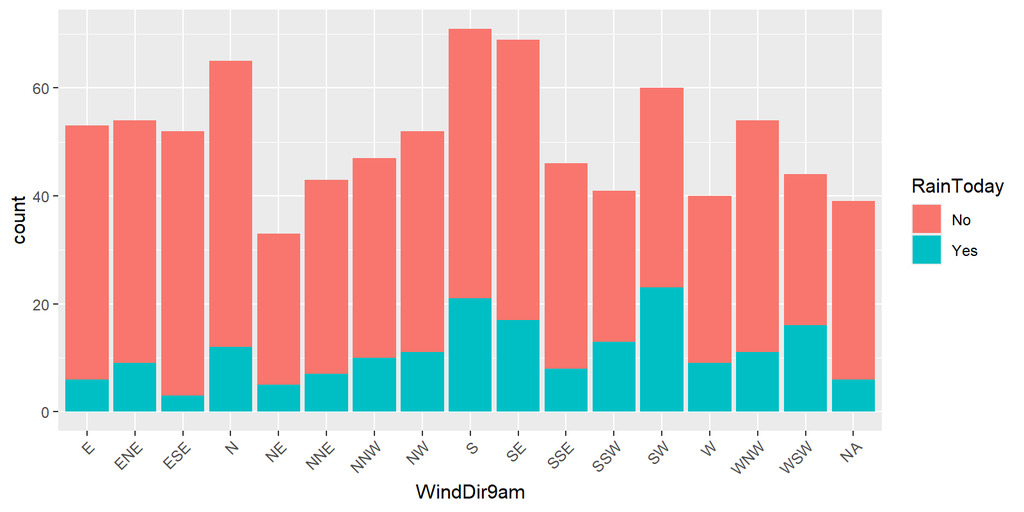

```r
ggplot(data=ds,aes(x=WindDir9am, fill=RainToday)) + geom_bar()+
  theme(axis.text.x=element_text(angle=45, hjust=1))
```

Las opciones para enriquecer los gráficos con **ggplot2** son muy amplias, poco a poco, usando esta librería para hacer gráficos te irás familiarizando con ellas.

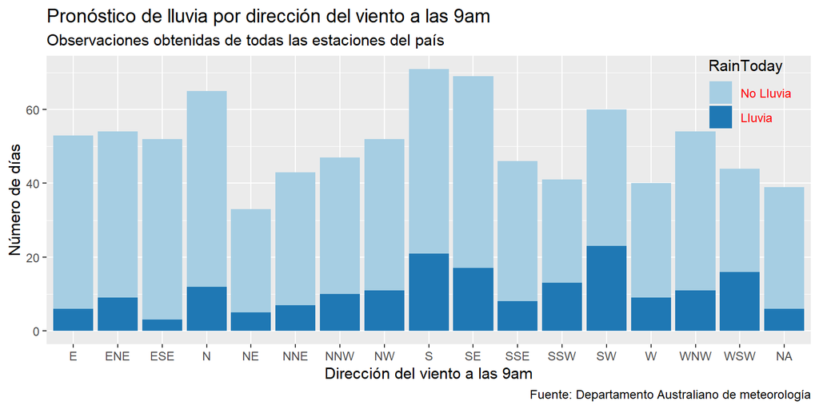

```r
library('RColorBrewer')
blues2 <- brewer.pal(4, "Paired")[1:2]

ggplot(data=ds, aes(x=WindDir9am, fill=RainToday)) + geom_bar() +
  scale_fill_manual(values=blues2,labels = c("No Lluvia", "Lluvia")) +
  theme(legend.position = c(.92, .87),
        legend.title=element_text(colour="black"),
        legend.text=element_text(colour="red"),
        legend.background = element_rect(fill="transparent")) +
  labs(title = "Pronóstico de lluvia por dirección del viento a las 9am",
     subtitle = "Observaciones obtenidas de todas las estaciones del país",
     caption  = "Fuente: Departamento Australiano de meteorología",
     x        = "Dirección del viento a las 9am",
     y        = "Número de días",
     fill     = "RainToday")
```

Igual no lo has percibido, pero la función **geom_bar()** de manera implícita, hace cálculos a partir de los datos para construir la representación. Por ejemplo, en los gráficos anteriores se ha calculado las frecuencias (cuentas) de cada valor de la dirección del viento. Estos cálculos se explicitan a través del argumento `stats` de las funciones `geom`. En los casos anteriores la opción por defecto es `stat="count"` que calcula frecuencias. Si el recuento ya está hecho y disponemos del número de repeticiones de cada categoría usaremos **geom_col**, o bien, **geom_bar(stat=‘identity’)**.

Vamos a ver un ejemplo de uso de otro valor del argumento `stat` . Queremos representar el valor medio de la variable `Temp9am` en función de la variable `Location`. La variable `Temp9am` es numérica (no categórica) y no tendría demasiado sentido utilizar el `stat="count"`.

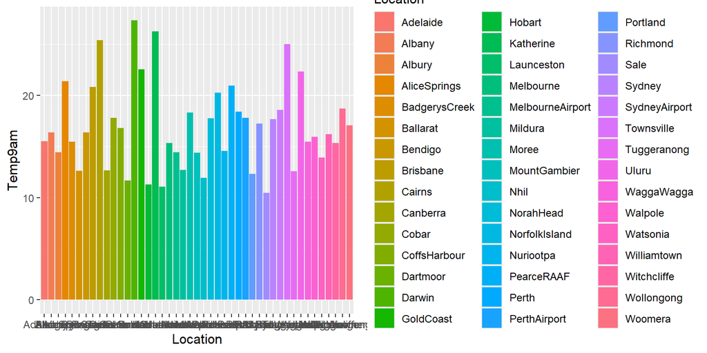

```r
ggplot(data=ds,aes(Location, Temp9am, fill=Location)) +
  geom_bar(stat="summary", fun="mean")
```

No se ven bien los valores de $x$ en el gráfico… Quitamos la leyenda y giramos las etiquetas de $x$ a 90 grados.

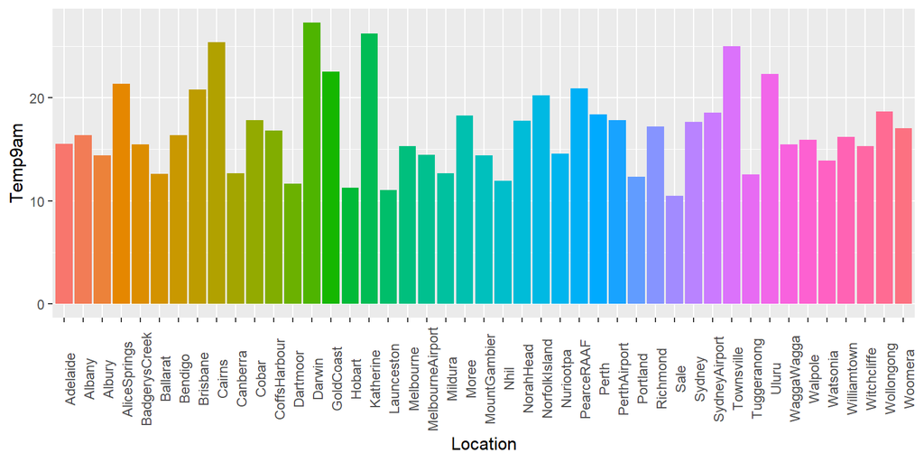

```r
ggplot(data=ds,aes(Location, Temp9am, fill=Location)) + #Muy colorido pero fill=Location es poco útil
  geom_bar(stat="summary", fun="mean") +
  theme(legend.position="none") +
  theme(axis.text.x=element_text(angle=90)) # probar la opción element_text(angle=90,hjust=1)
```

Podemos mostrar la gráfica ordenando las ciudades (`Location`) según el valor medio (`mean`) de la temperatura (`Temp9am`) en orden decreciente, usando la función **reorder**.  
Observa los otros elementos del gráfico y su efecto en el resultado.

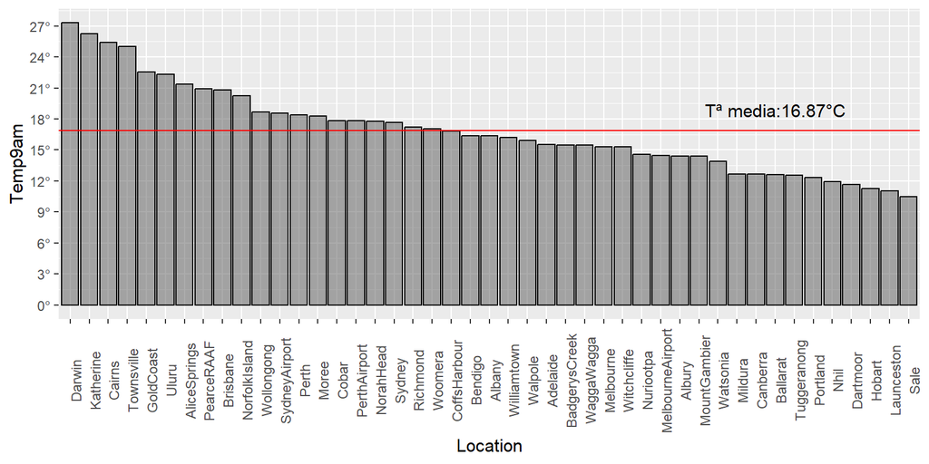

```r
#reorder: reordena el factor(Location) segun el resultado de aplicar FUN a Temp9a
ggplot(data=ds,aes(x=reorder(Location,Temp9am,FUN=mean,decreasing=TRUE), y=Temp9am)) +
  geom_bar(stat="summary", fun="mean",color='black',alpha=0.5) +
  geom_hline(yintercept = mean(ds$Temp9am),color='red')+
  #annotate permite añadir etiquetas fijas y puntuales en la coordenadas especificadas de un gráfico. En este caso x='Ballarat' es un valor de Location
  annotate("text", x='Ballarat', y=2+mean(ds$Temp9am), label=paste0('Tª media:',paste0(as.character(round(mean(ds$Temp9am),digits = 2))),'°C'))+
  theme(legend.position="none") +
  theme(axis.text.x=element_text(angle=90))+
  labs(x='Location')+
  scale_y_continuous(breaks = seq(0,30,by=3),labels = paste0(seq(0,30,by=3),'°'))
```